# Data Analytics Coursework_1 (ECS784P)

### Numerical Independent Variable vs Target Variable

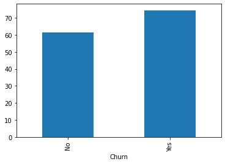

```python
df.groupby('Churn')['MonthlyCharges'].mean().plot.bar() # displays bar chart of monthly charges by churn rate
```

Churn rate vs the monthly charges shown in bar chart.

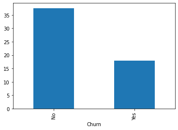

```python
df.groupby('Churn')['tenure'].mean().plot.bar() # displays bar chart of tenure by churn rate
```

Churn rate vs the tenure shown in bar chart.

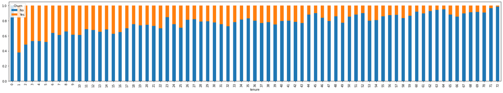

```python
df['x']=pd.cut(df['tenure'],1,0) # displays bar chart of tenure by churn data
x=pd.crosstab(df['tenure'],df['Churn'])
x.div(x.sum(1).astype(float), axis=0).plot(kind="bar",stacked=True,figsize=(30,5))
```

Here, the churn rate is shown for every tenure months. We can clearly notice that churn rate decreases with increase in tenure months.

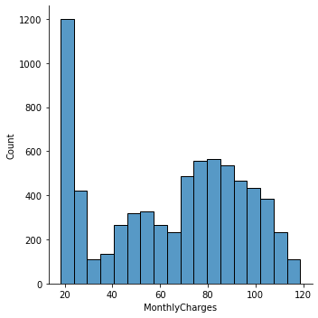

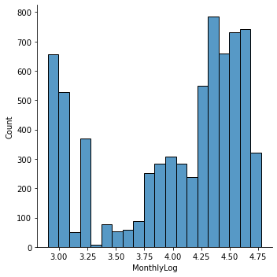

```python
sns.displot(df['MonthlyCharges']) # displays bar chart of monthly charges by count
df['MonthlyLog'] = np.log(df['MonthlyCharges'])
sns.displot(df['MonthlyLog']) # Let's view the log-scaled distributions of monthly charges by count
```

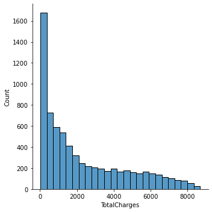

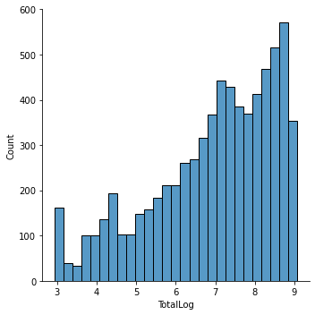

```python
sns.displot(df['TotalCharges'])# displays bar chart of total charges by count
df['TotalLog'] = np.log(df['TotalCharges'])
sns.displot(df['TotalLog']) # Let's view the log-scaled distributions of total charges by count
```

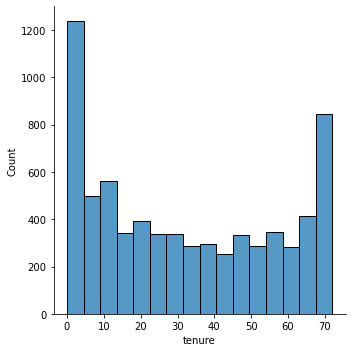

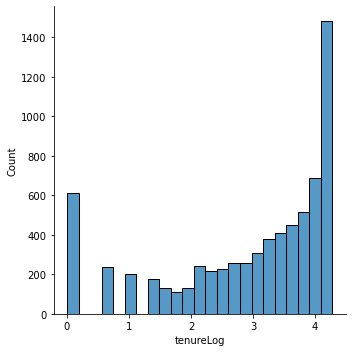

```python
sns.displot(df['tenure'])# displays bar chart of tenure by count
df['tenureLog'] = np.log(df['tenure'])
sns.displot(df['tenureLog']) # Let's view the log-scaled distributions of tenure by count
```

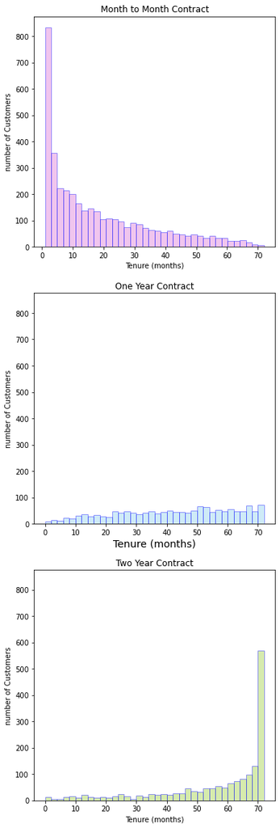

```python
fig, (ax1,ax2,ax3) = plt.subplots(nrows=3, ncols=1, sharey = True, figsize = (6,20))
# #displays the tenure months for month to month vs the count of customers
ax = sns.distplot(df[df['Contract']=='Month-to-month']['tenure'],hist=True, kde=False,bins=int(180/5), color = 'orchid',hist_kws={'edgecolor':'blue'},kde_kws={'linewidth': 4},ax=ax1)
ax.set_ylabel('number of Customers')
ax.set_xlabel('Tenure (months)')
ax.set_title('Month to Month Contract')

#displays the tenure months for one year contract vs the count of customers
ax = sns.distplot(df[df['Contract']=='One year']['tenure'],hist=True, kde=False,bins=int(180/5), color = 'skyblue',hist_kws={'edgecolor':'blue'},kde_kws={'linewidth': 4},ax=ax2)
ax.set_xlabel('Tenure (months)',size = 14)
ax.set_ylabel('number of Customers')
ax.set_title('One Year Contract')

#displays the tenure months for two year contract vs the count of customers
ax = sns.distplot(df[df['Contract']=='Two year']['tenure'],hist=True, kde=False,bins=int(180/5), color = 'yellowgreen',hist_kws={'edgecolor':'blue'},kde_kws={'linewidth': 4},ax=ax3)
ax.set_xlabel('Tenure (months)')
ax.set_ylabel('number of Customers')
ax.set_title('Two Year Contract')
```

Here, we can see three plots for month-to-month contract, one year contract and two year contract vs number of customers

```python
from sklearn.preprocessing import LabelEncoder #library to convert categorical data to integer values
```

```python
# setting integer values to all the below columns with categorical values
cols = ['gender','Partner','Dependents','MultipleLines','InternetService','OnlineSecurity','OnlineBackup','DeviceProtection','TechSupport','StreamingTV','StreamingMovies','PhoneService','Contract','PaperlessBilling','PaymentMethod','Churn']
le = LabelEncoder()                       # initialising the necessary function taken from the LabelEncoder library
for col in cols:                          # iterate over all variables in cols
    df[col] = le.fit_transform(df[col])   # convert categorical values into integer values
```

```python
df.head() # returns the first 5 lines of the dataframe
```

|  | gender | SeniorCitizen | Partner | Dependents | tenure | PhoneService | MultipleLines | InternetService | OnlineSecurity | OnlineBackup | ... | Contract | PaperlessBilling | PaymentMethod | MonthlyCharges | TotalCharges | Churn | x | MonthlyLog | TotalLog | tenureLog |
| --- | --- | --- | --- | --- | --- | --- | --- | --- | --- | --- | --- | --- | --- | --- | --- | --- | --- | --- | --- | --- | --- |
| 0 | 0 | 0 | 1 | 0 | 1 | 0 | 1 | 0 | 0 | 2 | ... | 0 | 1 | 2 | 29.85 | 29.85 | 0 | [0.0, 72.072) | 3.396185 | 3.396185 | 0.000000 |
| 1 | 1 | 0 | 0 | 0 | 34 | 1 | 0 | 0 | 2 | 0 | ... | 1 | 0 | 3 | 56.95 | 1889.50 | 0 | [0.0, 72.072) | 4.042174 | 7.544068 | 3.526361 |
| 2 | 1 | 0 | 0 | 0 | 2 | 1 | 0 | 0 | 2 | 2 | ... | 0 | 1 | 3 | 53.85 | 108.15 | 1 | [0.0, 72.072) | 3.986202 | 4.683519 | 0.693147 |
| 3 | 1 | 0 | 0 | 0 | 45 | 0 | 1 | 0 | 2 | 0 | ... | 1 | 0 | 0 | 42.30 | 1840.75 | 0 | [0.0, 72.072) | 3.744787 | 7.517928 | 3.806662 |
| 4 | 0 | 0 | 0 | 0 | 2 | 1 | 0 | 1 | 0 | 0 | ... | 0 | 1 | 2 | 70.70 | 151.65 | 1 | [0.0, 72.072) | 4.258446 | 5.021575 | 0.693147 |

5 rows × 24 columns

```python
df = df.drop(['x'],axis=1) # dropping the x variable because it is useless for prediction
```

```python
df = df.drop(['MonthlyLog'],axis=1) # We drop the monthlylog variable because it is useless for prediction
```

```python
df = df.drop(['TotalLog'],axis=1) # We drop the totallog because it is useless for prediction
df = df.drop(['tenureLog'],axis=1) # We drop the tenurelog because it is useless for prediction
df.head()
```

|  | gender | SeniorCitizen | Partner | Dependents | tenure | PhoneService | MultipleLines | InternetService | OnlineSecurity | OnlineBackup | DeviceProtection | TechSupport | StreamingTV | StreamingMovies | Contract | PaperlessBilling | PaymentMethod | MonthlyCharges | TotalCharges | Churn |
| --- | --- | --- | --- | --- | --- | --- | --- | --- | --- | --- | --- | --- | --- | --- | --- | --- | --- | --- | --- | --- |
| 0 | 0 | 0 | 1 | 0 | 1 | 0 | 1 | 0 | 0 | 2 | 0 | 0 | 0 | 0 | 0 | 1 | 2 | 29.85 | 29.85 | 0 |
| 1 | 1 | 0 | 0 | 0 | 34 | 1 | 0 | 0 | 2 | 0 | 2 | 0 | 0 | 0 | 1 | 0 | 3 | 56.95 | 1889.50 | 0 |
| 2 | 1 | 0 | 0 | 0 | 2 | 1 | 0 | 0 | 2 | 2 | 0 | 0 | 0 | 0 | 0 | 1 | 3 | 53.85 | 108.15 | 1 |
| 3 | 1 | 0 | 0 | 0 | 45 | 0 | 1 | 0 | 2 | 0 | 2 | 2 | 0 | 0 | 1 | 0 | 0 | 42.30 | 1840.75 | 0 |
| 4 | 0 | 0 | 0 | 0 | 2 | 1 | 0 | 1 | 0 | 0 | 0 | 0 | 0 | 0 | 0 | 1 | 2 | 70.70 | 151.65 | 1 |

### Correlation Matrix

Let's view the correlation between features

```python
corr=df.corr() # gives us the correlation values
```

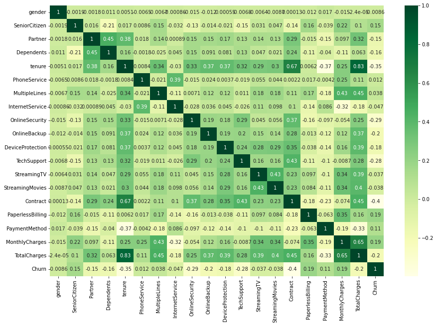

```python
plt.figure(figsize=(15,10))
sns.heatmap(corr, annot = True, cmap="YlGn")  # visualise the correlation matrix
```

Correlation matrix was plotted for all the column attributes and the correlation co-efficient was found with respect to other attributes. We can remove highly correlated features.

```python
# specify inputs 'x' and output 'y' attributes - target value
X = df.drop(['Churn'],axis=1)
y = df['Churn']
```

**k-best method**

```python
# using the k-best method to get to know the most highest predictive features of 'y' attribute
from sklearn.feature_selection import SelectKBest
from sklearn.feature_selection import chi2
```

```python
# passing x and y as inputs to the k-best method
k = SelectKBest(score_func = chi2, k = 'all')
features = k.fit(X,y)
```

```python
# new dataframe for the feature scores
orders = pd.DataFrame(features.scores_, columns=['scores'])
```

```python
#new dataframe for the feature feature_name
df_columns = pd.DataFrame(X.columns, columns = ['Feature_name'])
```

```python
#combining the above two feature dataframe into a dataframe
feature_rank = pd.concat([orders,df_columns],axis=1) # combine the two dataFrames
```

```python
#ranks displayed based on the scores and the chi2 scoring func for the 19 attribute columns
feature_rank.nlargest(19,'scores')
```

|  | scores | Feature_name |
| --- | --- | --- |
| 18 | 627147.530404 | TotalCharges |
| 4 | 16278.923685 | tenure |
| 17 | 3680.787699 | MonthlyCharges |
| 14 | 1115.780167 | Contract |
| 8 | 551.611529 | OnlineSecurity |
| 11 | 523.303866 | TechSupport |
| 9 | 230.086520 | OnlineBackup |
| 10 | 191.303140 | DeviceProtection |
| 1 | 134.351545 | SeniorCitizen |
| 3 | 133.036443 | Dependents |
| 15 | 105.680863 | PaperlessBilling |
| 2 | 82.412083 | Partner |
| 16 | 58.492250 | PaymentMethod |
| 7 | 9.821028 | InternetService |
| 6 | 9.746921 | MultipleLines |
| 13 | 8.235399 | StreamingMovies |
| 12 | 7.490203 | StreamingTV |
| 0 | 0.258699 | gender |
| 5 | 0.097261 | PhoneService |

Here, total charges is the most important feature that is necessary for prediction and the phone service feature is the least important feature.

```python
df.head()
```

|  | gender | SeniorCitizen | Partner | Dependents | tenure | PhoneService | MultipleLines | InternetService | OnlineSecurity | OnlineBackup | DeviceProtection | TechSupport | StreamingTV | StreamingMovies | Contract | PaperlessBilling | PaymentMethod | MonthlyCharges | TotalCharges | Churn |
| --- | --- | --- | --- | --- | --- | --- | --- | --- | --- | --- | --- | --- | --- | --- | --- | --- | --- | --- | --- | --- |
| 0 | 0 | 0 | 1 | 0 | 1 | 0 | 1 | 0 | 0 | 2 | 0 | 0 | 0 | 0 | 0 | 1 | 2 | 29.85 | 29.85 | 0 |
| 1 | 1 | 0 | 0 | 0 | 34 | 1 | 0 | 0 | 2 | 0 | 2 | 0 | 0 | 0 | 1 | 0 | 3 | 56.95 | 1889.50 | 0 |
| 2 | 1 | 0 | 0 | 0 | 2 | 1 | 0 | 0 | 2 | 2 | 0 | 0 | 0 | 0 | 0 | 1 | 3 | 53.85 | 108.15 | 1 |
| 3 | 1 | 0 | 0 | 0 | 45 | 0 | 1 | 0 | 2 | 0 | 2 | 2 | 0 | 0 | 1 | 0 | 0 | 42.30 | 1840.75 | 0 |
| 4 | 0 | 0 | 0 | 0 | 2 | 1 | 0 | 1 | 0 | 0 | 0 | 0 | 0 | 0 | 0 | 1 | 2 | 70.70 | 151.65 | 1 |

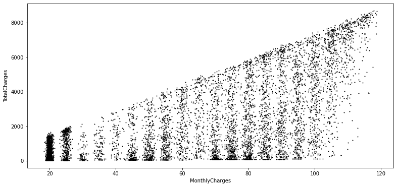

```python
# scatter plot of monthlycharges vs totalcharges
df[['MonthlyCharges', 'TotalCharges']].plot.scatter(x = 'MonthlyCharges',y='TotalCharges',color="black",s=1,figsize = (13,6))
```

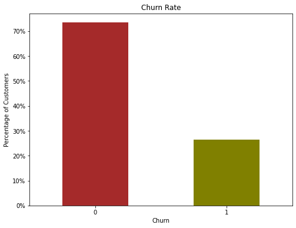

```python
# plotting the churn rate in percentage with respect to the number of customers
import matplotlib.ticker as mtick
colors = ['brown','olive']
ax = (df['Churn'].value_counts()*100.0 /len(df)).plot(kind='bar',stacked = True,rot = 0,color = colors,figsize = (8,6))
ax.yaxis.set_major_formatter(mtick.PercentFormatter())
ax.set_ylabel('Percentage of Customers')
ax.set_xlabel('Churn')
ax.set_title('Churn Rate')
```

The churn rate == true is 26.5 percent and churn rate == false is 73.5 percent.

**1. Logistic Regression**

```python
df_dummies = pd.get_dummies(df)
df_dummies.head()
```

|  | gender | SeniorCitizen | Partner | Dependents | tenure | PhoneService | MultipleLines | InternetService | OnlineSecurity | OnlineBackup | DeviceProtection | TechSupport | StreamingTV | StreamingMovies | Contract | PaperlessBilling | PaymentMethod | MonthlyCharges | TotalCharges | Churn |
| --- | --- | --- | --- | --- | --- | --- | --- | --- | --- | --- | --- | --- | --- | --- | --- | --- | --- | --- | --- | --- |
| 0 | 0 | 0 | 1 | 0 | 1 | 0 | 1 | 0 | 0 | 2 | 0 | 0 | 0 | 0 | 0 | 1 | 2 | 29.85 | 29.85 | 0 |
| 1 | 1 | 0 | 0 | 0 | 34 | 1 | 0 | 0 | 2 | 0 | 2 | 0 | 0 | 0 | 1 | 0 | 3 | 56.95 | 1889.50 | 0 |
| 2 | 1 | 0 | 0 | 0 | 2 | 1 | 0 | 0 | 2 | 2 | 0 | 0 | 0 | 0 | 0 | 1 | 3 | 53.85 | 108.15 | 1 |
| 3 | 1 | 0 | 0 | 0 | 45 | 0 | 1 | 0 | 2 | 0 | 2 | 2 | 0 | 0 | 1 | 0 | 0 | 42.30 | 1840.75 | 0 |
| 4 | 0 | 0 | 0 | 0 | 2 | 1 | 0 | 1 | 0 | 0 | 0 | 0 | 0 | 0 | 0 | 1 | 2 | 70.70 | 151.65 | 1 |

```python
df.head()
```

|  | gender | SeniorCitizen | Partner | Dependents | tenure | PhoneService | MultipleLines | InternetService | OnlineSecurity | OnlineBackup | DeviceProtection | TechSupport | StreamingTV | StreamingMovies | Contract | PaperlessBilling | PaymentMethod | MonthlyCharges | TotalCharges | Churn |
| --- | --- | --- | --- | --- | --- | --- | --- | --- | --- | --- | --- | --- | --- | --- | --- | --- | --- | --- | --- | --- |
| 0 | 0 | 0 | 1 | 0 | 1 | 0 | 1 | 0 | 0 | 2 | 0 | 0 | 0 | 0 | 0 | 1 | 2 | 29.85 | 29.85 | 0 |
| 1 | 1 | 0 | 0 | 0 | 34 | 1 | 0 | 0 | 2 | 0 | 2 | 0 | 0 | 0 | 1 | 0 | 3 | 56.95 | 1889.50 | 0 |
| 2 | 1 | 0 | 0 | 0 | 2 | 1 | 0 | 0 | 2 | 2 | 0 | 0 | 0 | 0 | 0 | 1 | 3 | 53.85 | 108.15 | 1 |
| 3 | 1 | 0 | 0 | 0 | 45 | 0 | 1 | 0 | 2 | 0 | 2 | 2 | 0 | 0 | 1 | 0 | 0 | 42.30 | 1840.75 | 0 |
| 4 | 0 | 0 | 0 | 0 | 2 | 1 | 0 | 1 | 0 | 0 | 0 | 0 | 0 | 0 | 0 | 1 | 2 | 70.70 | 151.65 | 1 |

```python
# We will use the data frame where we had created dummy variables
y = df_dummies['Churn'].values
X = df_dummies.drop(columns = ['Churn'])

# Scaling all the variables to a range of 0 to 1
from sklearn.preprocessing import MinMaxScaler
features = X.columns.values
scaler = MinMaxScaler(feature_range = (0,1))
scaler.fit(X)
X = pd.DataFrame(scaler.transform(X))
X.columns = features
```

```python
# Create Train & Test Data
from sklearn.model_selection import train_test_split
X_train, X_test, y_train, y_test = train_test_split(X, y, test_size=0.3, random_state=101)
```

```python
# Running logistic regression model
from sklearn.linear_model import LogisticRegression
model = LogisticRegression()
result = model.fit(X_train, y_train)
```

```python
#importing the metrics package
from sklearn import metrics
prediction_test = model.predict(X_test)
# Print the prediction accuracy
print(metrics.accuracy_score(y_test, prediction_test)*100)
```

```
80.50165641268339
```

For logistic regression we have got an accuracy of 80.50 percent.

```python
# printing all the metrics for analysis
print("Precision: "+str(round(metrics.precision_score(y_test,prediction_test.round())*100,5)))
print("Accuracy: "+str(round(metrics.accuracy_score(y_test,prediction_test.round())*100,5)))
print("Recall: "+str(round(metrics.recall_score(y_test,prediction_test.round(),average="binary")*100,5)))
print("F1 score: "+str(round(metrics.f1_score(y_test,prediction_test.round(),average="binary")*100,5)))
print("ROC_AUC: "+str(round(metrics.roc_auc_score(y_test,prediction_test.round())*100,5)))
```

```
Precision: 67.26058
Accuracy: 80.50166
Recall: 53.26279
F1 score: 59.44882
ROC_AUC: 71.87719
```

All metrics such as precision, accuracy, recall, F1_score and ROC_AUC was observed as above.

```
[[1399  147]
 [ 265  302]]
```

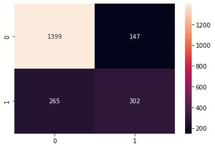

```python
# Create the Confusion matrix
from sklearn.metrics import classification_report, confusion_matrix
print(confusion_matrix(y_test,prediction_test))
cm = confusion_matrix(y_test,prediction_test)
ax= plt.subplot()
sns.heatmap(cm,annot=True,fmt='g',ax=ax)
# plots the confusion matrix
```

[TP - TRUE POSITIVE - 302 - Correctly predicted churn == Yes]  
[FP - FALSE POSITIVE - 147 - Falsely predicted churn == Yes]  
[TN - TRUE NEGATIVE - 1399 - Correctly predicted churn == No]  
[FN - FALSE NEGATIVE - 265 - Falsely predicted churn == No].

**K fold cross validation**

```python
# k fold cross validation where k = 10 here
from sklearn.model_selection import cross_val_score
accuracies = cross_val_score(estimator = model, X = X_train, y = y_train, cv = 10)
print("Accuracy: {:.2f} %".format(accuracies.mean()*100))
```

```
Accuracy: 79.84 %
```

The accuracy of logistic regression is 79.84 percent for k = 10 , 10 fold cross validation.

```python
# k fold cross validation where k=9
from sklearn.model_selection import cross_val_score
accuracies = cross_val_score(estimator = model, X = X_train, y = y_train, cv = 9)
print("Accuracy: {:.2f} %".format(accuracies.mean()*100))
```

```
Accuracy: 80.06 %
```

The recall score signifies the number of correct positive predictions made out of all positive predictions.  
Previously, we have got an recall score of 53.26 %. So we can increase this by making including class_weight = {0:1,1:2}. This will help to overcome any class imbalance in our dataset. model = LogisticRegression(class_weight={0:1,1:2})

```python
# We will use the data frame where we had created dummy variables
y = df_dummies['Churn'].values
X = df_dummies.drop(columns = ['Churn'])

# Scaling all the variables to a range of 0 to 1
from sklearn.preprocessing import MinMaxScaler
features = X.columns.values
scaler = MinMaxScaler(feature_range = (0,1))
scaler.fit(X)
X = pd.DataFrame(scaler.transform(X))
X.columns = features
```

```python
# Create Train & Test Data
from sklearn.model_selection import train_test_split
X_train, X_test, y_train, y_test = train_test_split(X, y, test_size=0.3, random_state=101)
```

```python
# Running logistic regression model
from sklearn.linear_model import LogisticRegression
model = LogisticRegression(class_weight={0:1,1:2})
result = model.fit(X_train, y_train)
```

```python
#importing the metrics package
from sklearn import metrics
prediction_test = model.predict(X_test)
# Print the prediction accuracy
print(metrics.accuracy_score(y_test, prediction_test)*100)
```

```
77.1888310459063
```

```python
print("Precision: "+str(round(metrics.precision_score(y_test,prediction_test.round())*100,5)))
print("Accuracy: "+str(round(metrics.accuracy_score(y_test,prediction_test.round())*100,5)))
print("Recall: "+str(round(metrics.recall_score(y_test,prediction_test.round(),average="binary")*100,5)))
print("F1 score: "+str(round(metrics.f1_score(y_test,prediction_test.round(),average="binary")*100,5)))
print("ROC_AUC: "+str(round(metrics.roc_auc_score(y_test,prediction_test.round())*100,5)))
```

```
Precision: 55.94406
Accuracy: 77.18883
Recall: 70.54674
F1 score: 62.4025
ROC_AUC: 75.08579
```

Although, the accuracy has drop a 3 percent the recall score went up noticeably from 53.26 to 70.54 percent.

**2. Support Vecor Machine (SVM)**

```python
# Create Train & Test Data
X_train, X_test, y_train, y_test = train_test_split(X, y, test_size=0.2, random_state=99)
```

```python
#Support Vector Machine for classification using SVC
from sklearn.svm import SVC

model.svm = SVC(kernel='linear')
model.svm.fit(X_train,y_train)
preds = model.svm.predict(X_test)
metrics.accuracy_score(y_test, preds)*100
```

```
78.21149751596877
```

For Support Vector Machine we have trained a model with accuracy of 78.21 percent.

```
[[910 113]
 [194 192]]
```

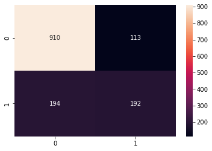

```python
# Create the Confusion matrix
from sklearn.metrics import classification_report, confusion_matrix
print(confusion_matrix(y_test,preds))
cm = confusion_matrix(y_test,preds)
ax= plt.subplot()
sns.heatmap(cm,annot=True,fmt='g',ax=ax)
# plots the confusion matrix
```

[TP - TRUE POSITIVE - 192 - Correctly predicted churn == Yes]  
[FP - FALSE POSITIVE - 113 - Falsely predicted churn == Yes]  
[TN - TRUE NEGATIVE - 910 - Correctly predicted churn == No]  
[FN - FALSE NEGATIVE - 194 - Falsely predicted churn == No].

```python
df['Churn'].value_counts()
```

```
0    5174
1    1869
Name: Churn, dtype: int64
```

```python
# performing k fold cross validation where K = 10 as most cases
from sklearn.model_selection import cross_val_score
accuracies = cross_val_score(estimator = model.svm, X = X_train, y = y_train, cv = 10)
print("Accuracy: {:.2f} %".format(accuracies.mean()*100))
```

```
Accuracy: 79.84 %
```

When we set the K-fold cross validation to 10 fold, we get an accuracy of 79.84 percent from 78.21 percent